# A3: SPL Library Checkouts

### Introduction

The dataset contains the count of checkouts from 2017 to 2022 based on the information provided by the Seattle Public Library. With the diverse catalogs given within the data, there were several possible trends we could discover. For those three data charts, I analyzed the trends of the most popular “material types” over the years, the trends of the number of checkouts for “usage classes” over the years, and the total number of checkouts over the years. The purpose of these analyses is to assist people in better understanding trends of products and to offer ideas if there are any changes or developments that library administrators might consider.

### Summary Information

Based on the values provided in the data, the average number of checkouts for physical items over the years is 1,676,405, and the average number for digital items is 1,465,816. This indicates that physical goods have been paid slightly more than digital goods over the past 6 years. Moreover, the year with the least checkouts for Ebook is 2017 with the number 440,127, and the year with the most checkout for Ebook is 2020 with the number 1,080,133. This rapid increment in that amount in just a few years astounded me a lot. Lastly, comparing the total number of checkouts between 2019 and 2020 with the calculation, it appears that the number has decreased by about 36% over the year.

### The Dataset

- Who collected/published the data?

The data was collected/published by “Seattle Open Data”

- What are the parameters of the data (dates, number of checkouts, kinds of books, etc.)?

UsageClass, CheckoutType, MaterialType, CheckoutYear, CheckoutMonth, Checkouts, Title, ISBN, Creator, Subjects, Publisher, and PublicationYear.

- How was the data collected or generated?

The data was collected and generated when items were checked out at the Seattle Public Library.

- Why was the data collected?

The data was collected for mainly tracking the library’s catalogs and resources.

- What, if any, ethical questions do you need to consider when working with this data?

The data collected about library checkouts may be subject to biases, such as biases in collection development or biases in how library staff interprets the data. It is important to be aware of these biases and take steps to mitigate them to ensure that the data is used ethically.

- What are possible limitations or problems with this data? (at least 200 words)

I found there are some possible limitations/problems with this data. One of them is that the data only counted the initial checkout. Renewals of physical items were not counted in this data set. To be specific, if a person borrows a book for a year, the library will only count the initial checkout. This book would not be counted as a checkout in the next 11 months, but it truly did not in the library. Data in Seattle public library was updated monthly, so the data could be incomplete due to missing information in the following 11 months. Another limitation was related to confidentiality and privacy. Library data may contain confidential and sensitive information about borrowers, including borrowing history and personal information. If the Seattle public library wanted to protect patrons’ privacy, many data would be unavailable and restricted its use for research and analysis. I also noticed that there were 32 material types were recorded, as a result of which the whole dataset would became extremely large and complex. People who were interested in certain topics had to spend time processing this data. Some possible problems with this data were incorrect data entry, data loss, and outdated data. Also, due to the different systems across libraries, library data could become inconsistent because of variations in data entry and classifications, which made it hard to analyze and compare data between different libraries.

### First Trends Over Time Chart

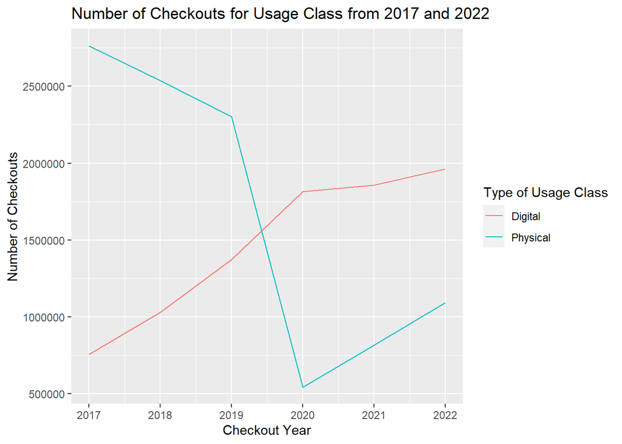

### Second Trends Over Time Chart

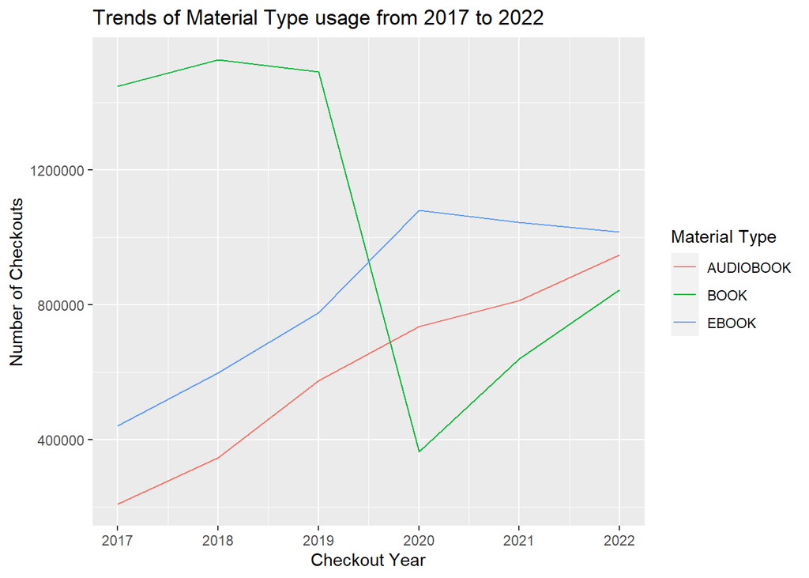

To give more insight into the previous chart, this time I made a line chart that visualizes the trend of specific types of items over the years. The reason for choosing this topic is to see which material types are consistently popular and which ones are becoming more or less popular over time. In 2017, it is clearly shown that checkouts for Books are much higher than for Ebooks and audiobooks. However, the situation has reversed since the year of the pandemic. The number of Book checkouts has dramatically declined while Ebooks and audiobooks were constantly growing up in 2020. This specifically reveals the flow of the previous chart, as the Book is cataloged in physical products whereas Ebooks and Audiobooks are considered digital products.

### Your Choice

[figure not shown]

This bar plot visualizes the total number of checkouts over the years. I decided to deal with this topic since I wanted to clarify how those pandemics impact the overall flow of checkout numbers. As can be seen from the data, the number of checkouts seemed likely to increase potentially through 2019, but, it has been felled off critically after the start of the pandemic in 2020. Moreover, the figure gradually recovers after several years, but still has not reached the previous record. Overall, the data indicate that the pandemic year has significantly impacted the total number of checkouts, although those digital items were shown to constantly increased.